# Schools should invest teachers into operating more classed rather than aiding existing regular-sized classes.

Rongwei Xia

03/10/2024

# 1 Abstract

In this report, effects of class size on grade 1 math scores is studied. Data source of this report is from the STAR project and raw data is obtained from The Harvard Dataverse A mixed effect model is constructed and two fixed effect models are also provided as comparison. Further investigation show that model fits the data well and preprocess methods are appropriate. Base on the model used, it can be shown that smaller class enhance grade 1 math scores.

# 2 Introduction

Recent studies have shown that smaller classes or larger teacher-to-student ratio can help improve test scores of students. The data set from the STAR project provides a perfect scope to investigate the effects of class size on test scores. There are multiple test scores in the data set and we focused on the grade 1 math score. To make full use of this data set, necessary data manipulation is conducted and various methods are applied. And they all serve one purpose. Our principle question of interest is whether there is any differences in math scaled scores in 1st grade across class types, and if so, a secondary question of interest is which class type is associated with the highest math scaled scores in 1st grade.

# 3 Background

The STAR project was conducted in the 1993 in Tennessee, USA where over 7,000 students and almost 80 schools are participated. The data was collected on a consecutive 4-year long window with subjects ranging from demographics, test scores, school & teacher information and other motivation/self-concept variables that may impact study performances. Within the study, teachers and students were randomly assigned to 3 class types: regular(22-25 students), small(13-17 students) and regular-with-aid. All schools must include at least one class of each type to participate. But technically this is not observed due to missing data.

However, the data from the STAR project was collected and analysed at students’ level. This may incur colinearity since teachers/classes have a major impact on the test scores and for students in the same class their scores are tend to correlate.

# 4 Initial Report

In the initial report, the model assumptions are likely to be violated but no further action is taken. To avoid this, model needs to be chosen more carefully before valid conclusions can be drawn.

# 5 Descriptive Analysis

From the STAR User guide, 1 = Small class, 2 = Regular Class, 3 = Regular with Aid. All data with empty grade 1 scaled math grade `g1tmathss` is dropped. All data are aggregated by grade 1 teacher id `g1tchid` and arithmetic mean is used as aggregated output.

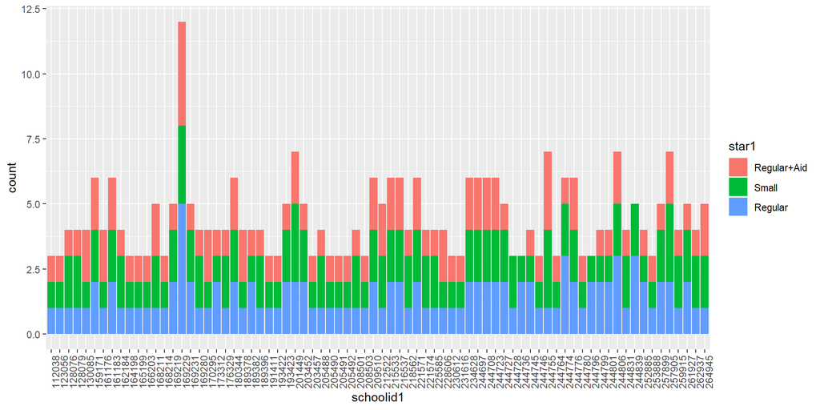

Figure above is the count of each class size in each school. From the figure above we can see that most school have all three types of classes, but some school only offers the regular and small class sizes.

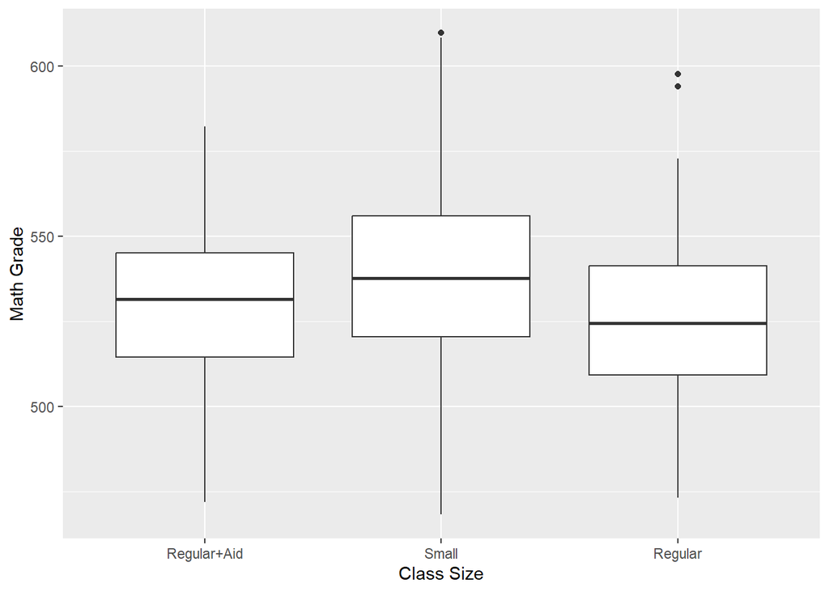

From the boxplot of math grade by class size we can see the small class size group has the best math grade. But the other two size groups are similar.

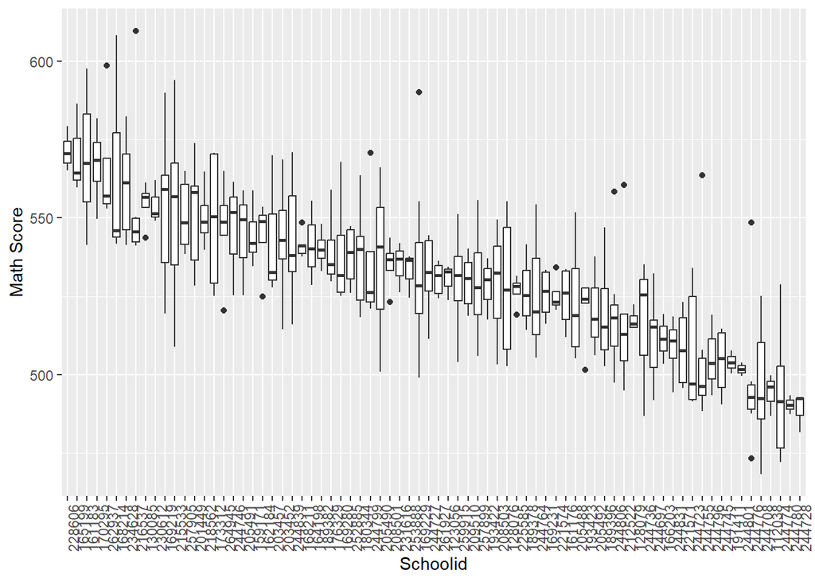

The figure above shows how math scores varies in different school. The school in the figure are organised in the descending order of average math score. There is a significant difference in math scores among schools.

# 6 Inferential analysis

## 6.1 Models

The two-way mixed model is constructed as followed:
$$Y_{ijk} = \mu_{..}+\alpha_i+\beta_j+\epsilon_{ijk}
\\k = 1,
\ldots,n_k,i= 1,\ldots,3,j = 1,\ldots,80$$
Where $\alpha$ is the fixed effect for class type and $\beta$ is the random effect for the school $\{\epsilon_{ijk}\} \sim N(0,\sigma^2),i.i.d$, $\{\beta_j\} \sim N(0,\sigma_\beta^2),i.i.d$ and $\{\epsilon_{ijk}\}$ and $\{\beta_j\}$ are mutually independent. $\sum\limits_{i = 1}^3\alpha_i = 0$

## 6.2 Model Justification

Since students and teachers are randomly selected, the school they are coming from are also randomly selected. Although we can observe a obvious impact of different school on math scores, they should serve as a random effect that may vary if a different sample is collected. The advantage of random effect is that it has far less parameters to be estimated. There are too many school in the data set so introducing it as the fixed effect will bring too many unnecessary parameters and may overfit the data. Given the fact that it is not the primary variable of interest, introducing it as a random effect will control its effect as a covariate while controlling variance inflation.

However, Introducing it as a random effect requires further normal assumption. We will take a closer look at it in the model diagnostic part.

The model summary of the model above is provided as below: In this model, the school takes $348.5/(348.5+276.8) = 55%$ of the total variance.

```
## Linear mixed model fit by REML ['lmerMod']
## Formula: y ~ star1 + (1 | schoolid1)
##    Data: data1
##
## REML criterion at convergence: 2996.2
##
## Scaled residuals:
##      Min       1Q   Median       3Q      Max
## -2.54012 -0.58167 -0.06987  0.49629  2.95883
##
## Random effects:
##  Groups    Name        Variance Std.Dev.
##  schoolid1 (Intercept) 348.5    18.67
##  Residual              276.8    16.64
## Number of obs: 339, groups:  schoolid1, 76
##
## Fixed effects:
##              Estimate Std. Error t value
## (Intercept)   528.263      2.740 192.811
## star1Small     11.005      2.271   4.846
## star1Regular   -2.395      2.323  -1.031
##
## Correlation of Fixed Effects:
##             (Intr) str1Sm
## star1Small  -0.462
## star1Regulr -0.455  0.547
```

## 6.3 Alternative Models.

On the other hand, alternative fixed effect models could be constructed as comparison. For this fixed effect model, the interaction effect between class size and school should be considered.

```
## [1] "Model1"
```

```
##                  Df Sum Sq Mean Sq F value   Pr(>F)
## star1             2  11617    5809  19.936 3.69e-08 ***
## schoolid1        75 136833    1824   6.262  < 2e-16 ***
## star1:schoolid1 146  38718     265   0.910    0.706
## Residuals       115  33507     291
## ---
## Signif. codes:  0 '***' 0.001 '**' 0.01 '*' 0.05 '.' 0.1 ' ' 1
```

```
## [1] "Model2"
```

```
##              Df Sum Sq Mean Sq F value   Pr(>F)
## star1         2  11617    5809  20.991 3.52e-09 ***
## schoolid1    75 136833    1824   6.593  < 2e-16 ***
## Residuals   261  72225     277
## ---
## Signif. codes:  0 '***' 0.001 '**' 0.01 '*' 0.05 '.' 0.1 ' ' 1
```

From the summary tables we can see that the school variable takes up to 75 D.F. and adding interaction term takes a further 146, leaving residual D.F. at only 115. This reduction of D.F. is totally unnecessary since introducing as random effect will take only one more D.F.

F test also suggest interaction may be dropped.

|  | #Df | LogLik | Df | Chisq | Pr(>Chisq) |
| --- | --- | --- | --- | --- | --- |
| 1 | 225 | -1259.618 | NA | NA | NA |
| 2 | 79 | -1389.800 | -146 | 260.3646 | 1.838731e-08 |

|  | Model1 | Model2 |
| --- | --- | --- |
| AIC | 2969.236 | 2937.601 |
| BIC | 3830.086 | 3239.855 |

Also, we can conduct a Likelihood Ratio Test to see if the interaction term should be kept in the fixed effect models. This time it rejects the null hypothesis and suggest the interaction term should be kept.

To take model overfitting into consideration, AIC and BIC are calculated. Model2 always has lower values and thus interaction term should be dropped.

Those two fixed effect models may also fit the data well. But due to large number of categories of schools, they do not achieve good bias-variance trade off. Thus, the mixed effect model is better than those two.

## 6.4 Results

```
## refitting model(s) with ML (instead of REML)
```

|  | npar | AIC | BIC | logLik | deviance | Chisq | Df | Pr(>Chisq) |
| --- | --- | --- | --- | --- | --- | --- | --- | --- |
| mod0 | 3 | 3052.259 | 3063.737 | -1523.130 | 3046.259 | NA | NA | NA |
| mod3 | 5 | 3016.342 | 3035.472 | -1503.171 | 3006.342 | 39.91752 | 2 | 2.147932e-09 |

First, the primary question of interest is examined using the chosen mixed effect model. A Likelihood Ratio Test is performed and the null hypothesis is rejected. And adding `star1` also decreases AIC and BIC. This suggests `star1` should be kept in the model. and there are differences in math scaled scores in 1st grade across class types.

```
##
##   Simultaneous Tests for General Linear Hypotheses
##
## Multiple Comparisons of Means: Tukey Contrasts
##
##
## Fit: lmer(formula = y ~ star1 + (1 | schoolid1), data = data1)
##
## Linear Hypotheses:
##                            Estimate Std. Error z value Pr(>|z|)
## Small - Regular+Aid == 0     11.005      2.271   4.846 2.51e-06 ***
## Regular - Regular+Aid == 0   -2.395      2.323  -1.031    0.302
## Regular - Small == 0        -13.400      2.186  -6.131 2.62e-09 ***
## ---
## Signif. codes:  0 '***' 0.001 '**' 0.01 '*' 0.05 '.' 0.1 ' ' 1
## (Adjusted p values reported -- holm method)
```

To exam the secondary question of interest, a Tukey HSD procedure can be implemented. The results show that `Small` size class beats both other sizes but there is no significant difference between `Regular` and `Regular+Aid`.

```
##                        diff     lwr    upr p adj
## Small-Regular+Aid     9.485   4.215 14.756 0.000
## Regular-Regular+Aid  -4.095  -9.456  1.267 0.172
## Regular-Small       -13.580 -18.656 -8.504 0.000
```

# 7 Model Diagnostics

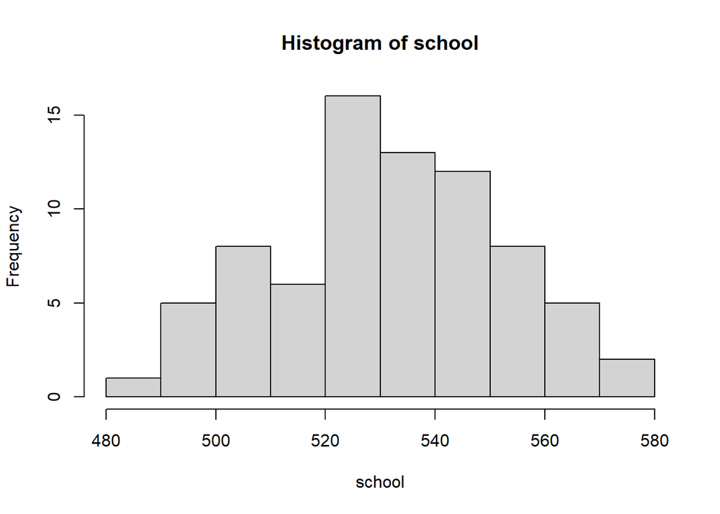

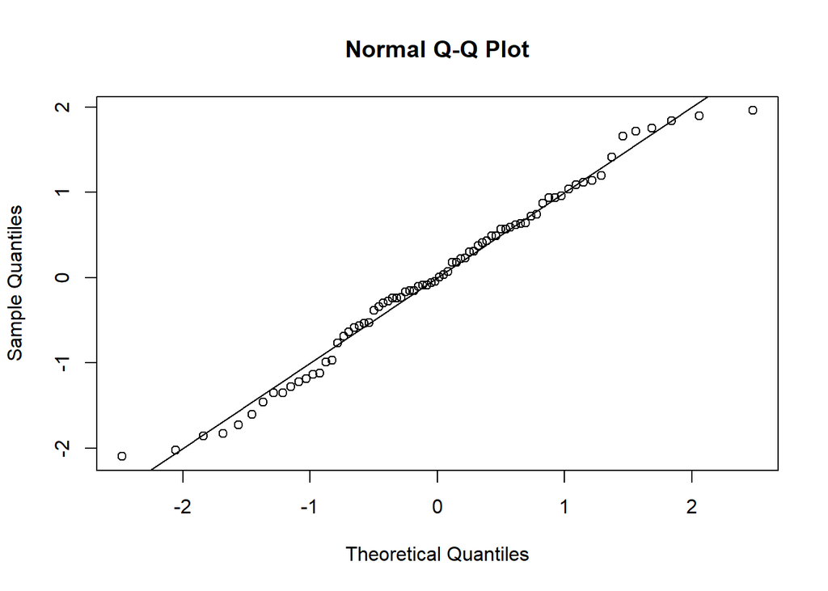

```
##
##  Shapiro-Wilk normality test
##
## data:  school
## W = 0.98319, p-value = 0.4125
```

Overall speaking, there is high probability that the normal assumption can be held.

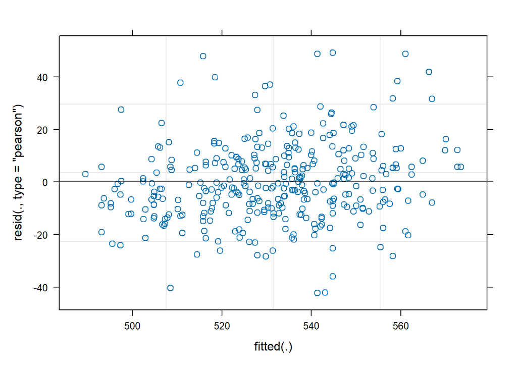

|  | Df | F value | Pr(>F) |
| --- | --- | --- | --- |
| group | 2 | 3.318977 | 0.03738004 |
|  | 336 | NA | NA |

The model variance is also tested. From the residual plot we can observe a flat and evenly distributed pattern. Although Levene test rejects the null hypothesis of equal varaince at a p value of 0.03. This implies there may be minor heteroscedasticity but the extend to which model assumptions are violated are mild.

# 8 Sensitivity Analysis

```
## Linear mixed model fit by REML ['lmerMod']
## Formula: y ~ star1 + (1 | schoolid1)
##    Data: data2
##
## REML criterion at convergence: 3035.1
##
## Scaled residuals:
##      Min       1Q   Median       3Q      Max
## -2.30528 -0.64680 -0.07502  0.56478  2.80440
##
## Random effects:
##  Groups    Name        Variance Std.Dev.
##  schoolid1 (Intercept) 384.3    19.60
##  Residual              312.1    17.67
## Number of obs: 339, groups:  schoolid1, 76
##
## Fixed effects:
##                  Estimate Std. Error t value
## (Intercept)      525.7985     2.8896 181.963
## star1Small        12.6253     2.4112   5.236
## star1Regular+Aid   0.2781     2.4662   0.113
##
## Correlation of Fixed Effects:
##             (Intr) str1Sm
## star1Small  -0.466
## str1Rglr+Ad -0.458  0.547
```

```
##
##   Simultaneous Tests for General Linear Hypotheses
##
## Multiple Comparisons of Means: Tukey Contrasts
##
##
## Fit: lmer(formula = y ~ star1 + (1 | schoolid1), data = data2)
##
## Linear Hypotheses:
##                            Estimate Std. Error z value Pr(>|z|)
## Small - Regular == 0        12.6253     2.4112   5.236 3.28e-07 ***
## Regular+Aid - Regular == 0   0.2781     2.4662   0.113     0.91
## Regular+Aid - Small == 0   -12.3471     2.3208  -5.320 3.11e-07 ***
## ---
## Signif. codes:  0 '***' 0.001 '**' 0.01 '*' 0.05 '.' 0.1 ' ' 1
## (Adjusted p values reported -- holm method)
```

In the data preprocessing part, arithmetic mean is used as the aggregate output for each class. To test sensitivity, median is used in stead and the same model is fitted. Comparing to the original model, this new model is quite similar, and all major conclusions still hold. Thus, the methods and approaches used in the report are robust.

# 9 Discussion and Conclusions

Based on the STAR data set, a mixed model with class type as fixed effect and school as random effect is constructed. And from the model there is a significant difference among different class types, controlling the effects different school may have on the math scores. Also, smaller classes are of irreplaceable importance in helping grade 1 students improving math scores. This also indicates schools should invest teachers into operating more classed rather than aiding existing regular-sized classes.

# Acknowledgement

# Reference

Imbens, G., & Rubin, D. (2015). Stratified Randomized Experiments. In Causal Inference for Statistics, Social, and Biomedical Sciences: An Introduction (pp. 187-218). Cambridge: Cambridge University Press. doi:10.1017/CBO9781139025751.010